# Term Project

Web scraping class

Viktória Kónya

16 December, 2021

## Introduction

In this report my goal is to analyze the top US universities focusing on the gender distribution, tuition fees and starting salaries that student can expect after graduation. The data of the universities was scraped from the usnews.com website’s university ranking page and was combined with more detailed information from each university’s subpage.The collected data was cleaned and visualizations were created in order to summarize the most important findings from the dataset.

**Best US Universities ranking** : https://www.usnews.com/best-colleges/rankings/national-universities

## Collecting the list of the university URLs using the websites API

In order to gather information from each university’s subpage on www.usnews.com, the list of URLs of the subpages needed to be extracted first from the university ranking page. Fortunately, after some research I found that the website provides API for the university rankings data so I requested the basic information of the universities using the website’s API. The API request can be done as seen below where the only changing parameter is the page number. Each returned JSON file contained the basic information from the rankings page of 10 universities. From the first JSON I could extract the total number of pages (max_iter) that I later used to iterate through all the pages (in total there were 392 universities, so I needed to make the request 40 times).

```r
# Use the page's API to get the number of pages
df <- fromJSON('https://www.usnews.com/best-colleges/api/search?_sort=rank&_sortDirection=asc&_page=1&schoolType=national-universities')
max_iter <- df$data$totalPages # Number of pages
```

Once I had the total number of pages, I could gather the basic university data with API requests. The difficulty that I faced was that the tuition fee information on the rankings site was stored differently in case of public and private universities. Public universities apply two different tuition fee schemes: out-of-state and in-state tuition fees while private schools have only one tuition fee. The two kinds of tuition fee information was stored in different places in the JSON string and for private schools this depth of information was not even available in the hierarchy. As the execution dropped for private schools I needed to add an error handling condition with `tryCatch`.

```r
# Define base URL
base <- "https://www.usnews.com"

# Create empty data frame for links and basic information
data <- data.frame(university_name = character(),
                   university_rank = character(),
                   university_primary_key = integer(),
                   state = character(),
                   city = character(),
                   zip = integer (),
                   link = character(),
                   tuition = character(),
                   tuition_in_out_of_state = character(),
                   undergrad_enrollment = character())


# Get all links and basic information
for (i in 1:max_iter) {

  # Get each page with API
  df <- fromJSON(paste0('https://www.usnews.com/best-colleges/api/search?_sort=rank&_sortDirection=asc&_page=', i ,'&schoolType=national-universities'))

  # Get links
  links <- df$data$items$institution$linkedDisplayName
  links <- gsub("\"", "", sub(">.*", "", gsub("<strong><a class=\"black90\" href=", "", links, fixed=TRUE)))

  # Out of and in state tuition fees
  tuition <- data.frame(tuition_in_out_of_state = character())

  for (j in 1:length(df$data$items$institution$linkedDisplayName)) {

    if(tryCatch(df[["data"]][["items"]][["searchData"]][["tuition"]][["displayValue"]][[j]][["value"]], error = function(e) FALSE) == FALSE){
      tuition_j <- NA
    }else{
      tuition_j <- paste0(df[["data"]][["items"]][["searchData"]][["tuition"]][["displayValue"]][[j]][["value"]], collapse = ", ")
    }

    tuition <- rbind(tuition, tuition_j)
    colnames(tuition) <- c("tuition_in_out_of_state")
    }

  # Insert into dataframe
  data_i <- data.frame(cbind(
              university_name = df$data$items$institution$displayName,
              university_rank = df$data$items$ranking$displayRank,
              university_primary_key = df$data$items$institution$primaryKey,
              state = df$data$items$institution$state,
              city = df$data$items$institution$city,
              zip = df$data$items$institution$zip,
              link = paste0(base, links),
              tuition = df$data$items$searchData$tuition$rawValue,
              tuition_in_out_of_state = tuition,
              undergrad_enrollment = df$data$items$searchData$enrollment$rawValue
              ))

  # Append to main dataset
  data <- rbind(data, data_i)

}


# Save dataset for future use
saveRDS(data, file = "raw/university_base.rds")

# Remove datasets
rm(list = c('data_i','df', 'max_iter', 'base', 'i', 'links', 'j', 'tuition', 'tuition_j'))
```

Let’s take a look at the dataset:

| university_name | university_rank | university_primary_key | state | city | zip | link | tuition | tuition_in_out_of_state | undergrad_enrollment |
| --- | --- | --- | --- | --- | --- | --- | --- | --- | --- |
| Princeton University | #1 | 2627 | NJ | Princeton | 08544 | https://www.usnews.com/best-colleges/princeton-university-2627 | 56010 | NA | 4773 |
| Columbia University | #2 | 2707 | NY | New York | 10027 | https://www.usnews.com/best-colleges/columbia-university-2707 | 63530 | NA | 6170 |
| Harvard University | #2 | 2155 | MA | Cambridge | 02138 | https://www.usnews.com/best-colleges/harvard-university-2155 | 55587 | NA | 5222 |
| Massachusetts Institute of Technology | #2 | 2178 | MA | Cambridge | 02139 | https://www.usnews.com/best-colleges/massachusetts-institute-of-technology-2178 | 55878 | NA | 4361 |
| Yale University | #5 | 1426 | CT | New Haven | 06520 | https://www.usnews.com/best-colleges/yale-university-1426 | 59950 | NA | 4703 |
| Stanford University | #6 | 1305 | CA | Stanford | 94305 | https://www.usnews.com/best-colleges/stanford-university-1305 | 56169 | NA | 6366 |

So now we have all the URLs of the university subpages and can start to collect more detailed information about the universities.

## Downloading and saving all HTMLs

The next step was that I had to iterate through all the scraped URLs and get the information from the universities’ subpages. The difficulty that I had here was that the HTMLs could not be read with the read_html() function in RStudio (it was running forever but never returned the HTML content). So, the solution I found was that I executed the HTML download part of the code in the base R console and saved all the downloaded HTMLs to my working directory. I commented out this part of the code intentionally (it was executed in R).

```r
# Execute the download in R console

#get_one_page <- function(url, name) {

   # Get link
   #t <- read_html(url)

   # Save HTML to working directory
   #(t, paste0(name, '.html'))

 #}

# Execute for all pages
#mapply(get_one_page, data$link , data$university_primary_key)
```

## Collecting data from university subpages

Once I had all the university HTMLs downloaded, I could start to extract the necessary information from the pages. As the JSON had very complex structure I found that the easiest way to identify the node IDs is by using the XPath syntax. From the university subpages I downloaded the content of the summary table as well as information about the median starting salaries, university admission and graduation statistics, class size and gender distribution of the institutions. The difficulty I had here was that the HTML pages were not exactly identical for each university so I needed to add if-else conditions to manage the empty nodes and collect the information for all universities.

```r
get_university_data <- function(html) {

  ### Primary key
  university_primary_key <- gsub("\\..*", "", html)

  ### Import html
  html_i <- read_html(html)

  ### General information part

  # Description
  description <- html_i %>%
    html_nodes(xpath = '//*[@id="app"]/div/div[3]/div[5]/div/div[1]/div/div/section[1]/div[1]/div[2]/p') %>%
    html_text()

  # School type
  school_type <- html_i %>%
    html_nodes(xpath = '//*[@id="app"]/div/div[3]/div[5]/div/div[1]/div/div/section[1]/react-trigger/div/div[1]/div[1]/div[1]/p[2]') %>%
    html_text()

  # Year founded
  year_founded <- html_i %>%
    html_nodes(xpath = '//*[@id="app"]/div/div[3]/div[5]/div/div[1]/div/div/section[1]/react-trigger/div/div[1]/div[1]/div[2]/p[2]') %>%
    html_text()

  # Religious Affiliation
  religious_affiliation <- html_i %>%
    html_nodes(xpath = '//*[@id="app"]/div/div[3]/div[5]/div/div[1]/div/div/section[1]/react-trigger/div/div[1]/div[1]/div[3]/p[2]') %>%
    html_text()

  # Academic calendar
  academic_calendar <- html_i %>%
    html_nodes(xpath = '//*[@id="app"]/div/div[3]/div[5]/div/div[1]/div/div/section[1]/react-trigger/div/div[1]/div[1]/div[4]/p[2]') %>%
    html_text()

  # Setting
  setting <- html_i %>%
    html_nodes(xpath = '//*[@id="app"]/div/div[3]/div[5]/div/div[1]/div/div/section[1]/react-trigger/div/div[1]/div[1]/div[5]/p[2]') %>%
    html_text()

  # Phone
  phone <- html_i %>%
    html_nodes(xpath = '//*[@id="app"]/div/div[3]/div[5]/div/div[1]/div/div/section[1]/react-trigger/div/div[1]/div[1]/div[6]/p[2]') %>%
    html_text()

  # Website
  school_website <- html_i %>%
    html_nodes(xpath = '//*[@id="app"]/div/div[3]/div[5]/div/div[1]/div/div/section[1]/react-trigger/div/div[1]/div[1]/div[7]/a') %>%
    html_attr('href')



  ### Median Starting Salary

  median_starting_salary_pre <- html_i %>%
    html_nodes(xpath = '//*[@id="app"]/div/div[3]/div[5]/div/div[1]/div/div/react-trigger[2]/section/div[2]/div[1]/p/a')
  median_starting_salary_pre2 <- html_i %>%
    html_nodes(xpath = '//*[@id="app"]/div/div[3]/div[5]/div/div[1]/div/div/react-trigger[3]/section/div[2]/div[1]/p/a')

  if(length(sub(".*>(.*)<.*","\\1",median_starting_salary_pre))>0) {
    median_starting_salary <- sub(".*>(.*)<.*","\\1",median_starting_salary_pre)
  }else{
    median_starting_salary <- sub(".*>(.*)<.*","\\1",median_starting_salary_pre2)
  }


  ### Admissions part

  # Admission description
  admission_description <- html_i %>%
    html_nodes(xpath = '//*[@id="admissions"]/div[1]/div/p[2]') %>%
    html_text()

  # Selectivity
  selectivity <- html_i %>%
    html_nodes(xpath = '//*[@id="admissions"]/div[2]/div[1]/p[2]/a') %>%
    html_text()

  # Acceptence rate
  if(length(html_i %>%
            html_nodes(xpath = '//*[@id="admissions"]/div[2]/div[2]/p[2]/a') %>%
            html_text())>0) {
    acceptance_rate <- html_i %>%
      html_nodes(xpath = '//*[@id="admissions"]/div[2]/div[2]/p[2]/a') %>%
      html_text()
  }else{
    acceptance_rate <- html_i %>%
      html_nodes(xpath = '//*[@id="admissions"]/div[2]/div[2]/p/a') %>%
      html_text()
  }

  # Application deadline
  application_deadline <- html_i %>%
    html_nodes(xpath = '//*[@id="admissions"]/div[2]/div[3]/p[2]/a') %>%
    html_text()



  ### Class size

  # Classes with fewer than 20 students - else N/A
  if(length( html_i %>%
             html_nodes(xpath = '//*[@id="academic-life"]/div[2]/div[1]/div[2]/div/div[1]/b') %>%
             html_text())>0) {
    class_size_20 <- html_i %>%
      html_nodes(xpath = '//*[@id="academic-life"]/div[2]/div[1]/div[2]/div/div[1]/b') %>%
      html_text()
  }else{
    class_size_20 <- NA
  }

  # Classes with fewer than 20-49 students - else N/A
  if(length( html_i %>%
             html_nodes(xpath = '//*[@id="academic-life"]/div[2]/div[1]/div[2]/div/div[2]/b') %>%
             html_text())>0) {
    class_size_20_49 <- html_i %>%
      html_nodes(xpath = '//*[@id="academic-life"]/div[2]/div[1]/div[2]/div/div[2]/b') %>%
      html_text()
  }else{
    class_size_20_49 <- NA
  }

  # Classes with fewer than 50+ students - else N/A
  if(length( html_i %>%
             html_nodes(xpath = '//*[@id="academic-life"]/div[2]/div[1]/div[2]/div/div[3]/b') %>%
             html_text())>0) {
    class_size_50 <- html_i %>%
      html_nodes(xpath = '//*[@id="academic-life"]/div[2]/div[1]/div[2]/div/div[3]/b') %>%
      html_text()
  }else{
    class_size_50 <- NA
  }

  # Student - faculty ratio
  if(length( html_i %>%
             html_nodes(xpath = '//*[@id="academic-life"]/div[2]/div[1]/p[2]') %>%
             html_text())>0) {
    student_faculty_ratio <- html_i %>%
      html_nodes(xpath = '//*[@id="academic-life"]/div[2]/div[1]/p[2]') %>%
      html_text()
  }else if(
    length(html_i %>%
           html_nodes(xpath = '//*[@id="academic-life"]/div[2]/div[2]/p[2]/a') %>%
           html_text())>0) {
    student_faculty_ratio <- html_i %>%
      html_nodes(xpath = '//*[@id="academic-life"]/div[2]/div[2]/p[2]/a') %>%
      html_text()
  }else{
    student_faculty_ratio <- html_i %>%
      html_nodes(xpath = '//*[@id="academic-life"]/div[2]/div[2]/p/a') %>%
      html_text()
  }



  ### Graduation rate

  graduation_rate <- html_i %>%
    html_nodes(xpath = '//*[@id="academic-life"]/div[2]/div[3]/p[2]/a') %>%
    html_text()



  ### Student life part

  # Male percentage
  if(length(  html_i %>%
              html_nodes(xpath = '//*[@id="student-life"]/div[2]/div[1]/div[2]/div/div[1]/b') %>%
              html_text())>0) {
    male <- html_i %>%
      html_nodes(xpath = '//*[@id="student-life"]/div[2]/div[1]/div[2]/div/div[1]/b') %>%
      html_text()
  }else{
    male <- 'N/A'
  }

  # Female percentage
  if(length(  html_i %>%
              html_nodes(xpath = '//*[@id="student-life"]/div[2]/div[1]/div[2]/div/div[2]/b') %>%
              html_text())>0) {
    female <- html_i %>%
      html_nodes(xpath = '//*[@id="student-life"]/div[2]/div[1]/div[2]/div/div[2]/b') %>%
      html_text()
  }else{
    female <- NA
  }



  ### Create dataframe

  uni_data <- data.frame(
    university_primary_key,
    description,
    school_type ,
    year_founded ,
    religious_affiliation ,
    academic_calendar ,
    setting ,
    phone ,
    school_website ,
    median_starting_salary ,
    admission_description ,
    selectivity ,
    acceptance_rate ,
    application_deadline ,
    class_size_20 ,
    class_size_20_49 ,
    class_size_50 ,
    student_faculty_ratio ,
    graduation_rate ,
    male ,
    female
  )

  return(uni_data)

}


# Append list of htmls
htmls <- paste0(data$university_primary_key, '.html')

# Create Df
uni_data <- lapply(htmls, get_university_data)
uni_data_appended <- data.frame(rbindlist(uni_data))

# Inner join
data_raw <- inner_join(data, uni_data_appended, by = "university_primary_key")


# Save dataset for future use
saveRDS(data_raw, file = "raw/university_raw.rds")

# Delete objects
rm(list = c('uni_data','uni_data_appended', 'htmls', 'get_university_data'))
```

Let’s take a look at the raw dataset:

university_name

university_rank

university_primary_key

state

city

zip

link

tuition

tuition_in_out_of_state

undergrad_enrollment

school_type

year_founded

religious_affiliation

academic_calendar

setting

phone

school_website

median_starting_salary

selectivity

acceptance_rate

application_deadline

class_size_20

class_size_20_49

class_size_50

student_faculty_ratio

graduation_rate

male

female

Princeton University

#1

2627

NJ

Princeton

08544

https://www.usnews.com/best-colleges/princeton-university-2627

56010

NA

4773

Private, Coed

1746

None

Semester

Suburban

609. 258-3000

http://www.princeton.edu

$71,300

Most selective

6%

Jan. 1

77.6%

13.5%

9%

4:1

90%

50%

50%

Columbia University

#2

2707

NY

New York

10027

https://www.usnews.com/best-colleges/columbia-university-2707

63530

NA

6170

Private, Coed

1754

None

Semester

Urban

212. 854-1754

http://www.columbia.edu

$67,800

Most selective

6%

Jan. 1

82.5%

8.6%

8.9%

6:1

86%

49%

51%

Harvard University

#2

2155

MA

Cambridge

02138

https://www.usnews.com/best-colleges/harvard-university-2155

55587

NA

5222

Private, Coed

1636

None

Semester

Urban

617. 495-1000

http://www.harvard.edu/

$69,000

Most selective

5%

Jan. 1

76.3%

13.6%

10%

5:1

86%

49%

51%

Massachusetts Institute of Technology

#2

2178

MA

Cambridge

02139

https://www.usnews.com/best-colleges/massachusetts-institute-of-technology-2178

55878

NA

4361

Private, Coed

1861

None

4-1-4

Urban

N/A

http://web.mit.edu/

$82,700

Most selective

7%

Jan. 1

70.1%

18.6%

11.3%

3:1

87%

52%

48%

Yale University

#5

1426

CT

New Haven

06520

https://www.usnews.com/best-colleges/yale-university-1426

59950

NA

4703

Private, Coed

1701

None

Semester

City

203. 432-4771

http://www.yale.edu/

$65,900

Most selective

7%

Jan. 2

76.9%

15.2%

7.9%

4:1

84%

50%

50%

Stanford University

#6

1305

CA

Stanford

94305

https://www.usnews.com/best-colleges/stanford-university-1305

56169

NA

6366

Private, Coed

1885

None

Quarter

Suburban

650. 723-2300

http://www.stanford.edu

$73,900

Most selective

5%

Jan. 2

68.6%

19.2%

12.2%

5:1

74%

49%

51%

## Data cleaning

The next step was that the scraped data needed to go through several data cleaning steps. The major data cleaning steps were the following:

- University website URLs needed to be cleaned from unnecessary slashes.
- The previously described in-state and out-of-state tuition fees needed to be split into two variables. Note that in case of public universities tuition = tuition_in_state.
- All fields in USD needed to be cleaned from the $ character and converted to numeric.
- All fields in percentage needed to be cleaned from the % character and converted to numeric.
- All NA values had to be converted to standard missing coding.
- A grouped school type variable was created for further visualizations.

```r
# Define new dataframe for clean dataset
data_clean <- data_raw

# University rank
data_clean$university_rank <- gsub("#", "", data_clean$university_rank) # Remove hashtag from ranking
# Tuition fee
data_clean$tuition_in_out_of_state <- gsub("[][',$]", "", data_clean$tuition_in_out_of_state) # Remove $ and comma
data_clean <- data_clean %>% separate(tuition_in_out_of_state, c("tuition_out_of_state","tuition_in_state"), sep = "([ ])") # Separate in and out of state tuition fee
data_clean$tuition_in_state <- as.numeric(data_clean$tuition_in_state)
data_clean$tuition_out_of_state <- as.numeric(data_clean$tuition_out_of_state)
# School type
data_clean$school_type <- gsub("N/A", NA, data_clean$school_type) # Replace NA
# Year founded
data_clean$year_founded <- gsub("N/A", NA, data_clean$year_founded) # Replace NA
# Academic calendar
data_clean$academic_calendar <- gsub("N/A", NA, data_clean$academic_calendar) # Replace NA
# Phone
data_clean$phone <- gsub("N/A", NA, data_clean$phone) # Replace NA
# School_website
data_clean$school_website <- trimws(data_clean$school_website, "left", '//') # Remove leading //
data_clean$school_website <- trimws(data_clean$school_website, "right", '/') # Remove ending /
# Medium starting salary
data_clean$median_starting_salary <- as.numeric(ifelse(data_clean$median_starting_salary %in% c('Median starting salary of alumni', 'N/A'), NA, gsub("[]['$,]", "", data_clean$median_starting_salary))) # Replace incorrect records and NA
# Acceptance rate
data_clean$acceptance_rate <- as.numeric(ifelse(data_clean$acceptance_rate %in% c('N/A'), NA, gsub("[]['%]", "", data_clean$acceptance_rate)))/100 # Replace NA, remove % and divide by 100
# Class size
data_clean$class_size_20 <- as.numeric(ifelse(data_clean$class_size_20 %in% c('N/A'), NA, gsub("[]['%]", "", data_clean$class_size_20)))/100 # Replace NA, remove % and divide by 100
data_clean$class_size_20_49 <- as.numeric(ifelse(data_clean$class_size_20_49 %in% c('N/A'), NA, gsub("[]['%]", "", data_clean$class_size_20_49)))/100
data_clean$class_size_50 <- as.numeric(ifelse(data_clean$class_size_50 %in% c('N/A'), NA, gsub("[]['%]", "", data_clean$class_size_50)))/100
# Graduation rate
data_clean$graduation_rate <- as.numeric(ifelse(data_clean$graduation_rate %in% c('N/A'), NA, gsub("[]['%]", "", data_clean$graduation_rate)))/100 # Replace NA, remove % and divide by 100
# Gender rates
data_clean$male <- as.numeric(ifelse(data_clean$male %in% c('N/A'), NA, gsub("[]['%]", "", data_clean$male)))/100 # Remove % and divide by 100
data_clean$female <- as.numeric(ifelse(data_clean$female %in% c('N/A'), NA, gsub("[]['%]", "", data_clean$female)))/100
# Create grouped field for school type
data_clean <- data_clean %>% mutate( school_type_group = case_when(
  school_type %in% c('Private, Coed', "Private, Women\'s college", "Private") ~ 'Private',
  school_type %in% c('Public, Coed', 'Public') ~ 'Public',
  school_type %in% c('Proprietary, Coed', 'Proprietary') ~ 'Proprietary')
  )


# Save dataset for future use
saveRDS(data_clean, file = "clean/university_clean.rds")
```

Let’s take a look at the clean dataset:

university_name

university_rank

university_primary_key

state

city

zip

link

tuition

tuition_out_of_state

tuition_in_state

undergrad_enrollment

school_type

year_founded

religious_affiliation

academic_calendar

setting

phone

school_website

median_starting_salary

selectivity

acceptance_rate

application_deadline

class_size_20

class_size_20_49

class_size_50

student_faculty_ratio

graduation_rate

male

female

school_type_group

Princeton University

1

2627

NJ

Princeton

08544

https://www.usnews.com/best-colleges/princeton-university-2627

56010

NA

NA

4773

Private, Coed

1746

None

Semester

Suburban

609. 258-3000

http://www.princeton.edu

71300

Most selective

0.06

Jan. 1

0.776

0.135

0.090

4:1

0.90

0.50

0.50

Private

Columbia University

2

2707

NY

New York

10027

https://www.usnews.com/best-colleges/columbia-university-2707

63530

NA

NA

6170

Private, Coed

1754

None

Semester

Urban

212. 854-1754

http://www.columbia.edu

67800

Most selective

0.06

Jan. 1

0.825

0.086

0.089

6:1

0.86

0.49

0.51

Private

Harvard University

2

2155

MA

Cambridge

02138

https://www.usnews.com/best-colleges/harvard-university-2155

55587

NA

NA

5222

Private, Coed

1636

None

Semester

Urban

617. 495-1000

http://www.harvard.edu

69000

Most selective

0.05

Jan. 1

0.763

0.136

0.100

5:1

0.86

0.49

0.51

Private

Massachusetts Institute of Technology

2

2178

MA

Cambridge

02139

https://www.usnews.com/best-colleges/massachusetts-institute-of-technology-2178

55878

NA

NA

4361

Private, Coed

1861

None

4-1-4

Urban

NA

http://web.mit.edu

82700

Most selective

0.07

Jan. 1

0.701

0.186

0.113

3:1

0.87

0.52

0.48

Private

Yale University

5

1426

CT

New Haven

06520

https://www.usnews.com/best-colleges/yale-university-1426

59950

NA

NA

4703

Private, Coed

1701

None

Semester

City

203. 432-4771

http://www.yale.edu

65900

Most selective

0.07

Jan. 2

0.769

0.152

0.079

4:1

0.84

0.50

0.50

Private

Stanford University

6

1305

CA

Stanford

94305

https://www.usnews.com/best-colleges/stanford-university-1305

56169

NA

NA

6366

Private, Coed

1885

None

Quarter

Suburban

650. 723-2300

http://www.stanford.edu

73900

Most selective

0.05

Jan. 2

0.686

0.192

0.122

5:1

0.74

0.49

0.51

Private

## Data visualization

Finally, we have a clean dataset that we can analyze.

### Top ranking universities

First, let’s take a look at the private and public universities with the highest ranking and their undergraduate enrollment.

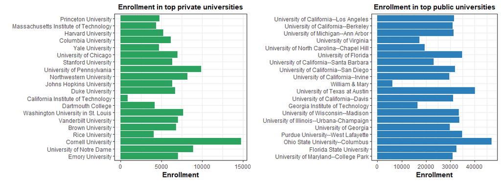

### Tuition fees by university type

Let’s move to the finances. The following three charts compare the distribution of the tuition fees of the institutions by university and financing type. As described earlier, public universities offer both out-of-state and in-state financing schemes that are shown separately in the charts.

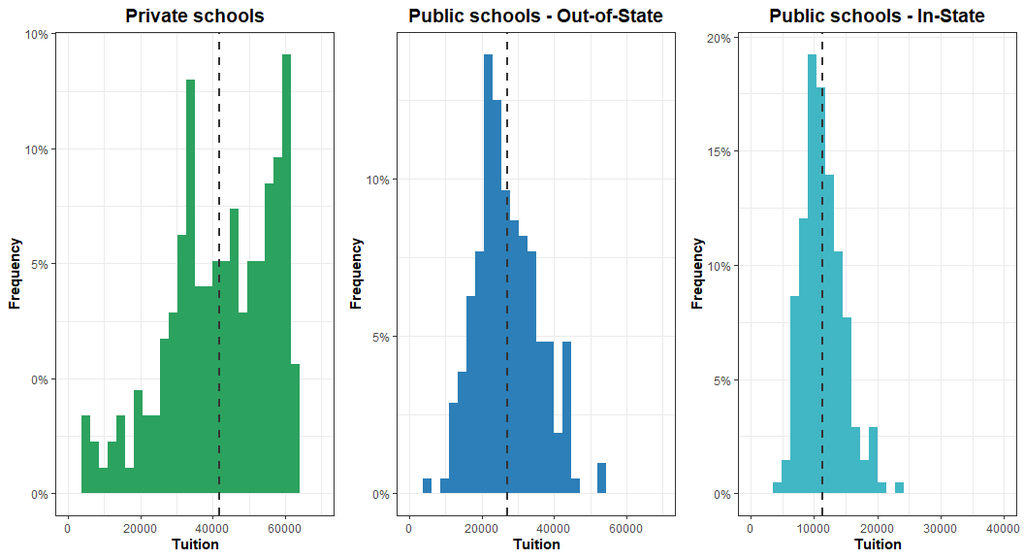

Private universities have an average tuition fee of about 40.000 USD, almost 4 times higher than the average cost that students who study in state-financed public universities have to pay. We can also see that the distributions are unimodal and raughly symmetric in case of the public universities, while private universities have two modes at about 30.000 USD and 60.000 USD.

### Top most expensive private schools

Let’s take a closer look at the most expansive universities. The next charts show the top 20 private and public universities with the highest tuition fees. I highlighted the universities with the 5 highest ranking in case of both school types.

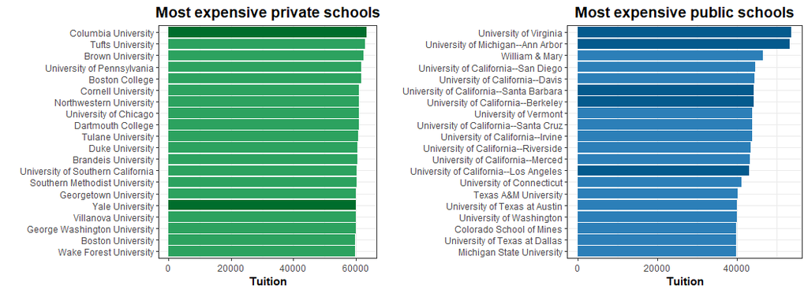

In case of the private universities it seems that the most expensive universities are not necessary the ones with the highest rankings. For example, Princeton University, which is the leading on the university ranking list is not even among the top 20 most expensive private universities with its 56.010 USD tuition fee. However, private universities apply very similar tuition fees so they are most probably not on the list because of the small difference in the tuition fees. In case of the public schools, on the other hand, it seems that the best universities are the most expansive ones.

### Relationship between the tuition fee and the median starting salary

The next two charts show the relationship between the the tuition fee and the median starting salary.

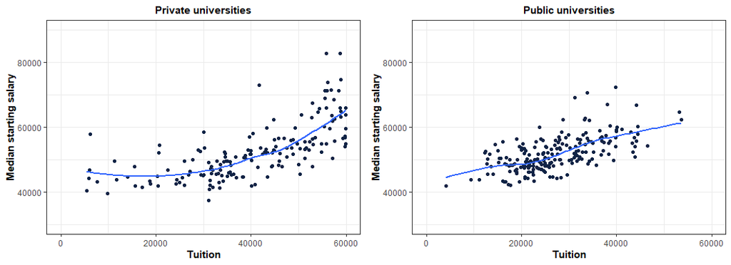

The loess fits imply that in case of the private schools the pattern of association is rather exponential, while in case of the public schools it is seemingly linear. Does it imply that if we pay more for the tuition than we can expect higher salaries in the future? Most probably not, as it rather shows the relationship between the salary and the quality of education, which is obviously higher at more expensive universities, and also the abilities of the students who are admitted to those universities.

### Top male and female dominated universities

Finally, let’s check which are the universities where the gender distribution is highly imbalanced.

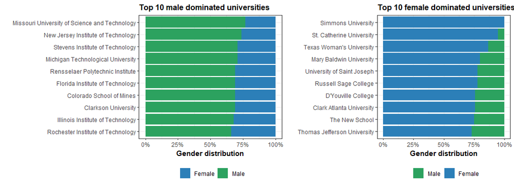